# Calibración de probabilidades

Evaluación y ajuste de predicciones probabilísticas mediante modelos de aprendizaje automático

Karina A. Bartolomé

Especialista en Métodos Cuantitativos para la Gestión y Análisis de Datos en Organizaciones (FCE, UBA). Lic. en Economía (FCE, UNLP). Líder técnica de Ciencia de Datos (Ualá).

**Organizadora: Natalia R. Salaberry**  
Doctoranda en la Universidad de Buenos Aires, Ciencias Económicas. Magister en Métodos Cuantitativos para la Gestión y Análisis de Datos en Organizaciones (FCE, UBA). Lic. en Economía, FCE, UBA. Investigadora en CIMBAGE (IADCOM), Docente de posgrados y Estadística I, FCE, UBA

**CIMBAGE (IADCOM)** - Facultad Ciencias Económicas (UBA)

2024-05-13

## 0.1 Consideraciones previas

[Repositorio](https://github.com/karbartolome/workshops)

- Se realizará una breve introducción a modelos de aprendizaje automático, pero se recomienda tener algún conocimiento previo para seguir el taller
- Durante el seminario se utilizarán los siguientes paquetes (**python**), con sus respectivas versiones.

**Librerías utilizadas**

```python
import pandas as pd
import numpy as np
import seaborn as sns
import matplotlib.pyplot as plt
from matplotlib.colors import ListedColormap, to_rgb
from great_tables import GT, from_column, style, loc
from collections import Counter

# from sklearn import datasets
# Modelado
from sklearn.model_selection import train_test_split
from sklearn.pipeline import Pipeline
from sklearn.compose import ColumnTransformer
from sklearn.compose import make_column_selector
from sklearn.preprocessing import StandardScaler, MinMaxScaler, OneHotEncoder
from sklearn.impute import SimpleImputer
from sklearn.linear_model import LogisticRegression
from sklearn.tree import DecisionTreeClassifier, plot_tree
from sklearn.ensemble import RandomForestClassifier, HistGradientBoostingClassifier
from sklearn.svm import SVC, LinearSVC
from sklearn.calibration import calibration_curve, CalibratedClassifierCV
from sklearn.metrics import (
    accuracy_score, precision_score, recall_score, f1_score,
    roc_auc_score,
    roc_curve,
    RocCurveDisplay,
    log_loss,
    recall_score,
    brier_score_loss,
    confusion_matrix,
    ConfusionMatrixDisplay,
)
from IPython.display import display, Markdown

# Funciones adicionales:
from functions import (
    plot_distribution,
    plot_calibration_models,
    plot_calibration,
    calibrate_model,
    calibration_table,
    calculate_clf_metrics,
)

import sklearn
sklearn.set_config(transform_output="pandas")
```

📦 pandas==2.2.3

📦 numpy==1.26.4

📦 scikit-learn==1.5.2

📦 matplotlib==3.9.2

📦 seaborn==0.13.2

📦 great_tables==0.10.0

# 1 Introducción al aprendizaje automático

## 1.1 Aprendizaje automático (*machine learning*)

En general al hablar de **aprendizaje automático** se hace referencia a diversos tipos de modelos. En la Figura 1 se muestra una clasificaicón comunmente utilizada<sup>1</sup>. En esta presentación se analizará el caso particular de los modelos de clasificación, haciendo énfasis en la estimación de probabilidad.

```
%%{init: {'flowchart' : {'curve' : 'linear'}}}%%

flowchart LR
    ml[Machine Learning]:::greenclass1
    supervised[Aprendizaje <br> supervisado]:::greenclass1
    unsupervised[Aprendizaje <br> no supervisado]
    reinforce[Aprendizaje <br> por refuerzo]

    ml_clf[Modelos de <br>clasificación]:::greenclass1
    ml_reg[Modelos de <br>regresión]
    ml_clfclass[Predicción de<br>clase]
    ml_clfrank[Predicción de<br>ordenamiento]
    ml_clfprob[Predicción de <br>probabilidad]:::greenclass2

    ml---temp1[ ]

    temp1-->supervised
    temp1-->unsupervised
    temp1-->reinforce

    supervised---temp2[ ]

    temp2-->ml_clf
    temp2-->ml_reg

    ml_clf---temp3[ ]

    temp3-->ml_clfclass
    temp3-->ml_clfrank
    temp3-->ml_clfprob

    classDef greenclass2 fill:#255255,stroke:#333,stroke-width:2px,color:white;
    classDef greenclass1 fill:#BDCBCC,stroke:#333,stroke-width:2px,color:black;
    style temp1 fill:#FFFFFF00,stroke:#FFFFFF00,height:0px,width:0px;
    style temp2 fill:#FFFFFF00,stroke:#FFFFFF00,height:0px,width:0px;
    style temp3 fill:#FFFFFF00,stroke:#FFFFFF00,height:0px,width:0px;
```

Figura 1: Tipos de modelos de aprendizaje automático

[^1]: Para una introducción a este tipo de modelos, ver James et al. (2023)

## 1.2 ¿Qué es un modelo de clasificación binaria?

Se busca predecir la ocurrencia de un evento a partir de ciertas características observables:

> $P(\color{red}{y}=1) = f(\color{blue}{X})$

> $\color{red}{y}$: *variable que puede tomar 2 valores: 0 o 1*

> $\color{blue}{X}$: *matriz nxm, siendo n la cantidad de observaciones y m la cantidad de variables (o atributos)*

**Ejemplos populares de modelos de clasificación:**

▪️**Iris**: Clasificación de especies de plantas

▪️**Breast Cancer Wisconsin (Diagnostic)**: Clasificación de tumores benignos o malignos

▪️**Titanic**: Clasificación de individuos en sobrevivientes y no sobrevivientes

▪️**German Credit**: Clasificación de individuos en riesgosos o no riesgosos

# 2 Caso: German Credit (Kaggle)

## 2.1 Datos

Caso ilustrativo: se utiliza el dataset German Credit por su valor didáctico y reproducibilidad. No representa necesariamente las variables ni modelos utilizados en sistemas crediticios reales.

**Código**

```python
PATH_DATA = '../../data/german_credit/df_german_credit.csv'
TARGET = "Risk"
df = (pd.read_csv(PATH_DATA)
  .drop('Unnamed: 0', axis=1)
  .assign(Risk = lambda x: np.where(x['Risk']=='good',0,1))
)
```

Se cuenta con un dataset de 1000 observaciones y 10 variables<sup>1</sup>.

**Código**

```python
def map_color(data):
    return (data[TARGET] == 1).map(
        {True: color_verde_claro, False: 'white'}
    )

(GT(df.sample(6, random_state=123)
        .set_index(TARGET)
        .reset_index()
    )
    .fmt_currency(columns="Credit amount")
    .tab_style(
        style=style.fill(color=map_color), locations=loc.body(columns=df.columns.tolist()),
    )
    .tab_style(
        style=style.text(color='red', weight = "bold"), locations=loc.body(TARGET),
    )
    .tab_options(
        column_labels_background_color=color_verde,
        table_font_names="Times New Roman"
    )
)
```

Tabla 1: Datos de German Credit (muestra de 6 observaciones)

| Risk | Age | Sex | Job | Housing | Saving accounts | Checking account | Credit amount | Duration | Purpose |
| --- | --- | --- | --- | --- | --- | --- | --- | --- | --- |
| 1 | 29 | male | 2 | own | little | little | $6,887.00 | 36 | education |
| 1 | 21 | male | 2 | rent | little | little | $902.00 | 12 | education |
| 0 | 29 | male | 1 | own |  | moderate | $2,333.00 | 24 | furniture/equipment |
| 1 | 20 | female | 2 | rent | little | little | $2,039.00 | 18 | furniture/equipment |
| 0 | 35 | male | 2 | own |  | moderate | $2,728.00 | 15 | radio/TV |
| 0 | 23 | male | 2 | own |  | moderate | $1,444.00 | 15 | radio/TV |

La variable objetivo (target) es Risk, donde el porcentaje de observaciones de clase 1 (riesgosos) es 30.0%

[^2]: Fuente de los datos: [Statlog (German Credit Data)](https://archive.ics.uci.edu/dataset/144/statlog+german+credit+data), en Kaggle en un formato más simple: [German Credit Risk - With Target](https://www.kaggle.com/datasets/kabure/german-credit-data-with-risk)

## 2.2 Particiones

Partición en dataset de entrenamiento, validación y evaluación.

- Dataset de **entrenamiento** –> Ajuste del modelo
- Dataset de **validación** –> Calibración del modelo
- Dataset de **evaluación** –> Métricas del modelo calibrado

**Generación de particiones**

```python
y = df[TARGET]
X = df.drop([TARGET], axis=1)

X_train, X_test, y_train, y_test = train_test_split(
    X, y, test_size=0.5, shuffle=True, stratify=y, random_state=42
)

# Lo ideal es utilizar la partición de validación para calibración
X_valid, X_test, y_valid, y_test = train_test_split(
    X_test, y_test, test_size=0.5, shuffle=True, stratify=y_test, random_state=42
)

display(Markdown(f"N observaciones en entrenamiento: {X_train.shape[0]}"))
display(Markdown(f"N observaciones en validación: {X_valid.shape[0]}"))
display(Markdown(f"N observaciones en evaluación: {X_test.shape[0]}"))
```

N observaciones en entrenamiento: 500

N observaciones en validación: 250

N observaciones en evaluación: 250

## 2.3 Modelo de clasificación simple

Se consideran 2 variables para ajustar un modelo de arbol de decisión con máxima profundidad=2

$$P(\text{Risk}=1) = f(\text{Credit amount}, \text{Age})$$

**Datos**

```python
subset_cols = ['Age', 'Credit amount']

(GT(pd.concat([y_train, X_train], axis=1)
        .sample(6, random_state=123)
        .set_index(TARGET)
        [subset_cols]
        .reset_index()
    )
    .fmt_currency(columns="Credit amount")
    .tab_style(
        style=style.fill(color=map_color), locations=loc.body(columns=df.columns.tolist()),
    )
    .tab_style(
        style=style.text(color='red', weight = "bold"), locations=loc.body(TARGET),
    )
    .tab_options(
        column_labels_background_color=color_verde,
        table_font_names="Times New Roman"
    )
)
```

Tabla 2: Datos de German Credit (2 variables)

| Risk | Age | Credit amount |
| --- | --- | --- |
| 0 | 37 | $1,287.00 |
| 1 | 27 | $8,648.00 |
| 1 | 34 | $1,337.00 |
| 0 | 48 | $2,134.00 |
| 1 | 48 | $1,082.00 |
| 0 | 53 | $2,424.00 |

**Ajuste del modelo**

```python
X_train_subset = X_train[subset_cols].copy()
clf = DecisionTreeClassifier(max_depth=2).fit(X_train_subset, y_train)
clf
```

```
DecisionTreeClassifier(max_depth=2)
```

**Árbol de decisión**

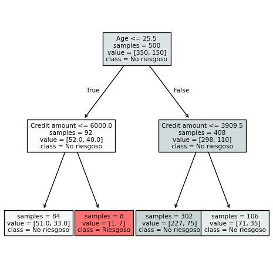

Figura 2: Visualización

```python
colors = [color_verde, 'red']
labels = ['No riesgoso','Riesgoso']
plt.figure(figsize=(6,6))
arbol = plot_tree(
    clf,
    filled=True,
    impurity=False,
    feature_names=X_train_subset.columns.tolist(),
    class_names=labels,
    fontsize=8
)
plt.gcf().canvas.draw()  # force render so annotation bbox patches exist (newer matplotlib)
# plot_tree also returns "True"/"False" edge-label annotations (no bbox) near the
# root, which throws off a plain zip() with tree_.impurity/value; keep only node boxes
nodos = [a for a in arbol if a.get_bbox_patch() is not None]
for i, impurity, value in zip(nodos, clf.tree_.impurity, clf.tree_.value):
    # let the max value decide the color; whiten the color depending on impurity (gini)
    r, g, b = to_rgb(colors[np.argmax(value)])
    f = impurity * 2 # for N colors: f = impurity * N/(N-1) if N>1 else 0
    i.get_bbox_patch().set_facecolor((f + (1-f)*r, f + (1-f)*g, f + (1-f)*b))
    i.get_bbox_patch().set_edgecolor('black')
plt.show()
```

## 2.4 Evaluación de un modelo de clasificación

Dados los datos de evaluación, se utiliza el modelo para predecir el valor de la variable objetivo. Mediante `predict()` se obtienen las predicciones de clase. Con `predict_proba()`el clasificador devuelve un score (valor entre 0 y 1).

**Predicciones sobre la partición de evaluación**

```python
preds = (pd.concat([y_test, X_test], axis=1)
    .set_index(TARGET)
    [subset_cols]
    .reset_index()
    .assign(
        Risk_pred = clf.predict(X_test[subset_cols]),
        Risk_pred_prob = clf.predict_proba(X_test[subset_cols])[:,1]
    )
)
```

**Display**

```python
(GT(preds.sample(6, random_state=2).round(2))
    .fmt_currency(columns="Credit amount")
    .tab_style(
        style=style.fill(color=map_color), locations=loc.body(columns=df.columns.tolist()),
    )
    .tab_style(
        style=style.text(color='red', weight = "bold"), locations=loc.body(TARGET),
    )
    .tab_options(
        column_labels_background_color=color_verde,
        table_font_names="Times New Roman"
    )
)
```

Tabla 3: Predicciones

| Risk | Age | Credit amount | Risk_pred | Risk_pred_prob |
| --- | --- | --- | --- | --- |
| 0 | 40 | $3,939.00 | 0 | 0.33 |
| 1 | 43 | $2,625.00 | 0 | 0.25 |
| 1 | 27 | $5,998.00 | 0 | 0.33 |
| 0 | 60 | $2,032.00 | 0 | 0.25 |
| 1 | 23 | $15,672.00 | 1 | 0.88 |
| 1 | 59 | $6,416.00 | 0 | 0.33 |

**Clases predichas**

```python
display(GT(preds
    .groupby(['Risk','Risk_pred'], as_index=False).size()
    .pivot(index='Risk', columns='Risk_pred', values='size')
    .rename({0:'0',1:'1'}, axis=1)
    .reset_index()
    )
    .tab_spanner('Risk_pred', columns = ['0','1'])
    .data_color(
        columns=['0','1'],
        domain=[0,X.shape[0]],
        palette=[color_verde_claro, 'red'],
        na_color="white",
    )
)
```

Tabla 4: Matriz de confusión

| Risk | Risk_pred |  |
| --- | --- | --- |
|  | 0 | 1 |
| 0 | 172 | 3 |
| 1 | 71 | 4 |

**Probabilidades predichas**

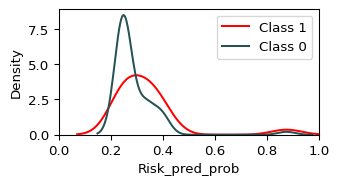

Figura 3: Distribución de “probabilidad” predicha

```python
distrib=plot_distribution(
    data=preds,
    obs_column='Risk',
    pred_column='Risk_pred_prob',
    class_0_color=color_verde
)
distrib
```

## 2.5 Evaluación de un modelo de clasificación (Cont.)

En la Figura 4 se presentan distintas métricas de clasificación. En este caso el foco estará sobre las métricas basadas en probabilidad.

```
%%{init: {'flowchart' : {'curve' : 'linear'}}}%%

flowchart LR
    ml[Modelo de <br>clasificación]
    metrics[Métricas]

    ml_clfclass[Predicción de<br>clase]
    ml_clfrank[Predicción de<br>ordenamiento]
    ml_clfprob[Predicción de <br>probabilidad]:::greenclass2

    ml-->metrics
    metrics---temp1[ ]

    temp1-->ml_clfclass
    temp1-->ml_clfrank
    temp1-->ml_clfprob

    ml_clfclass---temp2[ ]
    temp2-->accuracy
    temp2-->precision
    temp2-->etc

    ml_clfrank---temp3[ ]
    temp3-->roc_auc

    ml_clfprob---temp4[ ]
    temp4-->log_loss:::greenclass2
    temp4-->brier_loss:::greenclass2

    classDef greenclass2 fill:#255255,stroke:#333,stroke-width:2px,color:white;
    classDef greenclass1 fill:#BDCBCC,stroke:#333,stroke-width:2px,color:black;
    style temp1 fill:#FFFFFF00,stroke:#FFFFFF00,height:0px,width:0px;
    style temp2 fill:#FFFFFF00,stroke:#FFFFFF00,height:0px,width:0px;
    style temp3 fill:#FFFFFF00,stroke:#FFFFFF00,height:0px,width:0px;
    style temp4 fill:#FFFFFF00,stroke:#FFFFFF00,height:0px,width:0px;
```

Figura 4: Métricas de modelos de clasificación

## 2.6 Evaluación de un modelo de clasificación (Cont.)

Siendo $N$ la cantidad de observaciones, $y_i$ el valor observado para la obseravción $i$ y $\hat{y_i}$ el valor predicho para la observación $i$, se definen las funciones de pérdida:

- Log loss
- Brier loss

También denominada Negative Mean Log-Likelihood

$$\text{Log Loss} = -\frac{1}{N} \sum_{i=1}^{N} \left( \color{red}{y_i \log(\hat{y_i})} + \color{blue}{(1 - y_i) \log(1 - \hat{y_i})} \right)$$

> Si $y_i=1$ => $\text{Log Loss}_{i}=-\color{red}{\log(\hat{y_i})}$

> Si $y_i=0$ => $\text{Log Loss}_{i}=-\color{blue}{\log(1 - \hat{y_i})}$
- La pérdida es 0 si se tiene seguridad sobre una predicción y la predicción es correcta
- La pérdida es $\infty$ si se tiene seguridad sobre una predicción y la predicción es incorrecta

**Log(prob)**

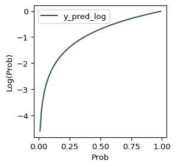

Figura 5: Logatitmo de una probabilidad

```python
N=100
temp = (pd.DataFrame({
    'y_pred':[i/N for i in range(1,N,1)]
    })
    .assign(y_pred_log = lambda x: np.log(x['y_pred']))
    .plot(
    x='y_pred', y='y_pred_log',
    figsize=(3,3),
    xlabel='Prob', ylabel='Log(Prob)',
    color=color_verde
    )
);
```

Error Cuadrático Medio pero para clasificación:

$$\text{Brier Loss} = \frac{1}{N} \sum_{i=1}^{N} (y_i - \hat{y_i})^2$$

# 3 Comparación de modelos de ML

## 3.1 Preprocesamiento

Muchos modelos de aprendizaje automático requieren que los datos sean numéricos. Para ello, se construye un pipeline de preprocesamiento de variables, diferenciando el procesamiento según tipo de variables: categóricas y numéricas.

🔗 [sklearn.preprocessing](https://scikit-learn.org/stable/modules/preprocessing.html)

**Preprocesador**

```python
numeric_transformer = Pipeline([
    ('impute', SimpleImputer(strategy='median')),
    ('scaler', MinMaxScaler())
])

categorical_transformer = Pipeline([
    ('ohe',OneHotEncoder(
        min_frequency=0.05,
        drop='if_binary',
        handle_unknown='infrequent_if_exist',
        sparse_output=False)
    )
])

preproc = ColumnTransformer([
    ('num', numeric_transformer,
      make_column_selector(dtype_include=['float','int'])),
    ('cat', categorical_transformer,
      make_column_selector(dtype_include=['object','category']))
], verbose_feature_names_out=False)
```

```
ColumnTransformer(transformers=[('num',
                                 Pipeline(steps=[('impute',
                                                  SimpleImputer(strategy='median')),
                                                 ('scaler', MinMaxScaler())]),
                                 <sklearn.compose._column_transformer.make_column_selector object at 0x141f34620>),
                                ('cat',
                                 Pipeline(steps=[('ohe',
                                                  OneHotEncoder(drop='if_binary',
                                                                handle_unknown='infrequent_if_exist',
                                                                min_frequency=0.05,
                                                                sparse_output=False))]),
                                 <sklearn.compose._column_transformer.make_column_selector object at 0x141f345c0>)],
                  verbose_feature_names_out=False)
```

En la Tabla 5 se visualizan los datos luego del preprocesamiento. Esta es la matriz que será utilizada para ajustar múltiples modelos de clasificación.

**Datos preprocesados**

```python
display(GT(preproc.fit_transform(X_train).sample(2).round(2))
    .tab_options(
        column_labels_background_color=color_verde,
        table_font_names="Times New Roman"
    )
)
```

Tabla 5: Datos de German Credit preprocesados (muestra de 2 observaciones)

| Age | Job | Credit amount | Duration | Sex_male | Housing_free | Housing_own | Housing_rent | Saving accounts_little | Saving accounts_moderate | Saving accounts_quite rich | Saving accounts_rich | Saving accounts_nan | Checking account_little | Checking account_moderate | Checking account_rich | Checking account_nan | Purpose_business | Purpose_car | Purpose_furniture/equipment | Purpose_radio/TV | Purpose_infrequent_sklearn |
| --- | --- | --- | --- | --- | --- | --- | --- | --- | --- | --- | --- | --- | --- | --- | --- | --- | --- | --- | --- | --- | --- |
| 0.14 | 0.67 | 0.07 | 0.25 | 0.0 | 0.0 | 1.0 | 0.0 | 1.0 | 0.0 | 0.0 | 0.0 | 0.0 | 0.0 | 1.0 | 0.0 | 0.0 | 0.0 | 0.0 | 1.0 | 0.0 | 0.0 |
| 0.52 | 0.67 | 0.05 | 0.14 | 1.0 | 0.0 | 1.0 | 0.0 | 1.0 | 0.0 | 0.0 | 0.0 | 0.0 | 1.0 | 0.0 | 0.0 | 0.0 | 0.0 | 1.0 | 0.0 | 0.0 | 0.0 |

## 3.2 Modelado

Se ajustan distintos tipos de modelos reutilizando el mismo `pipeline` de preprocesamiento de datos:

**Generador de pipelines**

```python
def gen_pipe(model):
    pipe = Pipeline([
        ('preproc', preproc),
        ('model',model)
    ])
    return pipe
```

**Especificación de modelos**

```python
pipe_hist = gen_pipe(
    model = HistGradientBoostingClassifier(
        max_depth=4, learning_rate=0.1, max_iter=1000,
        random_state=42,
    )
)
pipe_hist_balanced = gen_pipe(
    model = HistGradientBoostingClassifier(
        max_depth=4, learning_rate=0.1, max_iter=1000, class_weight='balanced',
        random_state=42,
    )
)
pipe_tree = gen_pipe(model = DecisionTreeClassifier(random_state=42))
pipe_reglog = gen_pipe(model = LogisticRegression(random_state=42))
pipe_reglog_balanced = gen_pipe(model = LogisticRegression(random_state=42, class_weight='balanced'))
pipe_svc = gen_pipe(model = SVC(random_state=42, probability=True))
```

**Diccionario de modelos**

```python
models_dict = {
    'Hist gradient boosting': pipe_hist,
    'Decision tree': pipe_tree,
    'Logistc regression': pipe_reglog,
    'SVC': pipe_svc,
    'Logistc regression (balanced)': pipe_reglog_balanced,
    'Hist gradient boosting (balanced)': pipe_hist_balanced
}
```

- Hist gradient boosting
- Decision tree
- Logistc regression
- SVC
- Logistc regression (balanced)
- Hist gradient boosting (balanced)

```
Pipeline(steps=[('preproc',
                 ColumnTransformer(transformers=[('num',
                                                  Pipeline(steps=[('impute',
                                                                   SimpleImputer(strategy='median')),
                                                                  ('scaler',
                                                                   MinMaxScaler())]),
                                                  <sklearn.compose._column_transformer.make_column_selector object at 0x141f34620>),
                                                 ('cat',
                                                  Pipeline(steps=[('ohe',
                                                                   OneHotEncoder(drop='if_binary',
                                                                                 handle_unknown='infrequent_if_exist',
                                                                                 min_frequency=0.05,
                                                                                 sparse_output=False))]),
                                                  <sklearn.compose._column_transformer.make_column_selector object at 0x141f345c0>)],
                                   verbose_feature_names_out=False)),
                ('model',
                 HistGradientBoostingClassifier(max_depth=4, max_iter=1000,
                                                random_state=42))])
```

```
Pipeline(steps=[('preproc',
                 ColumnTransformer(transformers=[('num',
                                                  Pipeline(steps=[('impute',
                                                                   SimpleImputer(strategy='median')),
                                                                  ('scaler',
                                                                   MinMaxScaler())]),
                                                  <sklearn.compose._column_transformer.make_column_selector object at 0x141f34620>),
                                                 ('cat',
                                                  Pipeline(steps=[('ohe',
                                                                   OneHotEncoder(drop='if_binary',
                                                                                 handle_unknown='infrequent_if_exist',
                                                                                 min_frequency=0.05,
                                                                                 sparse_output=False))]),
                                                  <sklearn.compose._column_transformer.make_column_selector object at 0x141f345c0>)],
                                   verbose_feature_names_out=False)),
                ('model', DecisionTreeClassifier(random_state=42))])
```

```
Pipeline(steps=[('preproc',
                 ColumnTransformer(transformers=[('num',
                                                  Pipeline(steps=[('impute',
                                                                   SimpleImputer(strategy='median')),
                                                                  ('scaler',
                                                                   MinMaxScaler())]),
                                                  <sklearn.compose._column_transformer.make_column_selector object at 0x141f34620>),
                                                 ('cat',
                                                  Pipeline(steps=[('ohe',
                                                                   OneHotEncoder(drop='if_binary',
                                                                                 handle_unknown='infrequent_if_exist',
                                                                                 min_frequency=0.05,
                                                                                 sparse_output=False))]),
                                                  <sklearn.compose._column_transformer.make_column_selector object at 0x141f345c0>)],
                                   verbose_feature_names_out=False)),
                ('model', LogisticRegression(random_state=42))])
```

```
Pipeline(steps=[('preproc',
                 ColumnTransformer(transformers=[('num',
                                                  Pipeline(steps=[('impute',
                                                                   SimpleImputer(strategy='median')),
                                                                  ('scaler',
                                                                   MinMaxScaler())]),
                                                  <sklearn.compose._column_transformer.make_column_selector object at 0x141f34620>),
                                                 ('cat',
                                                  Pipeline(steps=[('ohe',
                                                                   OneHotEncoder(drop='if_binary',
                                                                                 handle_unknown='infrequent_if_exist',
                                                                                 min_frequency=0.05,
                                                                                 sparse_output=False))]),
                                                  <sklearn.compose._column_transformer.make_column_selector object at 0x141f345c0>)],
                                   verbose_feature_names_out=False)),
                ('model', SVC(probability=True, random_state=42))])
```

```
Pipeline(steps=[('preproc',
                 ColumnTransformer(transformers=[('num',
                                                  Pipeline(steps=[('impute',
                                                                   SimpleImputer(strategy='median')),
                                                                  ('scaler',
                                                                   MinMaxScaler())]),
                                                  <sklearn.compose._column_transformer.make_column_selector object at 0x141f34620>),
                                                 ('cat',
                                                  Pipeline(steps=[('ohe',
                                                                   OneHotEncoder(drop='if_binary',
                                                                                 handle_unknown='infrequent_if_exist',
                                                                                 min_frequency=0.05,
                                                                                 sparse_output=False))]),
                                                  <sklearn.compose._column_transformer.make_column_selector object at 0x141f345c0>)],
                                   verbose_feature_names_out=False)),
                ('model',
                 LogisticRegression(class_weight='balanced', random_state=42))])
```

```
Pipeline(steps=[('preproc',
                 ColumnTransformer(transformers=[('num',
                                                  Pipeline(steps=[('impute',
                                                                   SimpleImputer(strategy='median')),
                                                                  ('scaler',
                                                                   MinMaxScaler())]),
                                                  <sklearn.compose._column_transformer.make_column_selector object at 0x141f34620>),
                                                 ('cat',
                                                  Pipeline(steps=[('ohe',
                                                                   OneHotEncoder(drop='if_binary',
                                                                                 handle_unknown='infrequent_if_exist',
                                                                                 min_frequency=0.05,
                                                                                 sparse_output=False))]),
                                                  <sklearn.compose._column_transformer.make_column_selector object at 0x141f345c0>)],
                                   verbose_feature_names_out=False)),
                ('model',
                 HistGradientBoostingClassifier(class_weight='balanced',
                                                max_depth=4, max_iter=1000,
                                                random_state=42))])
```

## 3.3 Evaluación

Se calculan las métricas de cada uno de los modelos:

**Cálculo de métricas de evaluación**

```python
metrics_df = pd.DataFrame()
for i in models_dict.keys():
    pipe = models_dict.get(i)
    preds = pd.DataFrame({
        'y_true': y_test,
        'y_pred': pipe.predict(X_test),
        'y_pred_prob': pipe.predict_proba(X_test)[:,1],
    })
    m = calculate_clf_metrics(
        preds['y_true'], preds['y_pred'], preds['y_pred_prob'],
        name=i
    ).reset_index().rename({'index':'Modelo'},axis=1)
    metrics_df = pd.concat([metrics_df, m], axis=0, ignore_index=True)
```

**Display de métricas**

```python
(GT(metrics_df.round(2))
    .data_color(
        columns=['Accuracy','Precision','Recall','F1','ROC AUC'],
        palette=[color_verde_claro, color_verde]
    )
    .data_color(
        columns=['Log Loss','Brier Loss'], palette=['white', 'red']
    )
    .tab_spanner(
        label="Clasificación",
        columns=["Accuracy","Recall","Precision","F1"]
    )
    .tab_spanner(
        label="Ordenamiento",
        columns=["ROC AUC"]
    )
    .tab_spanner(
        label="Probabilidad",
        columns=["Log Loss", "Brier Loss"]
    )
)
```

Tabla 6: Métricas de los modelos en la partición de evaluación

| Modelo | Clasificación |  |  |  | Ordenamiento | Probabilidad |  |
| --- | --- | --- | --- | --- | --- | --- | --- |
|  | Accuracy | Recall | Precision | F1 | ROC AUC | Log Loss | Brier Loss |
| Hist gradient boosting | 0.72 | 0.53 | 0.53 | 0.53 | 0.74 | 0.93 | 0.22 |
| Decision tree | 0.7 | 0.45 | 0.51 | 0.48 | 0.63 | 10.67 | 0.3 |
| Logistc regression | 0.74 | 0.45 | 0.59 | 0.51 | 0.75 | 0.53 | 0.18 |
| SVC | 0.73 | 0.32 | 0.6 | 0.42 | 0.71 | 0.55 | 0.19 |
| Logistc regression (balanced) | 0.64 | 0.69 | 0.44 | 0.54 | 0.75 | 0.6 | 0.21 |
| Hist gradient boosting (balanced) | 0.71 | 0.59 | 0.52 | 0.55 | 0.74 | 0.98 | 0.23 |

## 3.4 Problema organizacional

> ¿Cuán útiles son las predicciones de probabilidad del modelo?

Se utiliza el modelo para generar predicciones sobre las observaciones de test (Tabla 7), agrupando las predicciones en 5 intervalos de probabilidad. La Tabla 8 contiene la cantidad de observaciones por bin y el promedio de y_obs e y_pred. En la Figura 6 se visualiza la probabilidad promedio por bin en el eje x y la fracción de clase positiva observada en el eje y.

**Preds**

```python
preds_df = (pd.DataFrame({
        'y_obs':y_test,
        'y_pred':pipe_hist.predict_proba(X_test)[:,1]
    })
    .assign(bin=lambda x: pd.qcut(x['y_pred'],q=5, precision=5))
)
preds_df['bin'] = pd.IntervalIndex(preds_df['bin']).map(lambda x: pd.Interval(round(x.left, 2), round(x.right, 2)))
(GT(preds_df
    .sample(3, random_state=123).round(4))
    .tab_options(
        column_labels_background_color=color_verde,
        table_font_names="Times New Roman"
    )
)
```

Tabla 7: Predicciones

| y_obs | y_pred | bin |
| --- | --- | --- |
| 0 | 0.1315 | (0.02, 0.23] |
| 0 | 0.0 | (-0.0, 0.0] |
| 1 | 0.6428 | (0.23, 0.84] |

**Bins**

```python
(GT(preds_df.groupby('bin')
    .agg(
        N = ('y_obs','count'),
        frac_positive=('y_obs','mean'),
        avg_pred = ('y_pred','mean')
    ).round(2).reset_index()
    )
    .tab_options(
        column_labels_background_color=color_verde,
        table_font_names="Times New Roman"
    )
)
```

Tabla 8: Bins de las predicciones

| bin | N | frac_positive | avg_pred |
| --- | --- | --- | --- |
| (-0.0, 0.0] | 50 | 0.08 | 0.0 |
| (0.0, 0.02] | 50 | 0.14 | 0.01 |
| (0.02, 0.23] | 50 | 0.28 | 0.08 |
| (0.23, 0.84] | 50 | 0.4 | 0.51 |
| (0.84, 1.0] | 50 | 0.6 | 0.95 |

**Calibración**

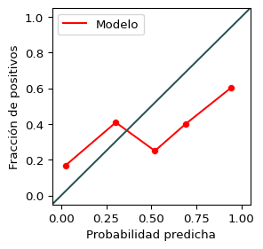

Figura 6: Gráfico de calibración (Reliability diagram)

```python
from sklearn.calibration import calibration_curve
prob_true, prob_pred = calibration_curve(
    y_test, pipe_hist.predict_proba(X_test)[:,1],
    n_bins=5,
    strategy='uniform'
)
plt.figure(figsize=(3,3))
sns.lineplot(x=prob_pred, y=prob_true, color='red', label='Modelo')
sns.scatterplot(x=prob_pred, y=prob_true, color='red')
plt.axline([0, 0], [1, 1], c=color_verde)
plt.legend()
plt.xlabel("Probabilidad predicha")
plt.ylabel("Fracción de positivos");
```

# 4 Calibración de probabilidades

## 4.1 Calibración de probabilidades

**Objetivo:**

Se busca encontrar una función que ajuste la relación entre los scores predichos por el modelo (predict_proba) y las probabilidades reales

> $P(y_i=1)= f(z_i)$

> Siendo: $P(y_{i}=1)$ la probabilidad calibrada para el individuo $i$ y $z_{i}$ el output del modelo no calibrado (score)

Un clasificador binario bien calibrado debería clasificar de forma tal que para las observaciones que predice un score (predict_proba) = 0.8, se espera que un 80% de las observaciones correspondan a la clase positiva (1).

**Referencias:**

- [Calibración de probabilidades en {scikit-learn} 📦](https://scikit-learn.org/stable/modules/calibration.html)

## 4.2 Calibración de probabilidades (Cont.)

**Métodos de calibración**

Calibración Sigmoide (Platt scaling)

Calibración Isotónica

Calibración Beta (Nuevo)

Calibración Spline (Nuevo)

## 4.3 Calibración sigmoide (Platt scaling)

Este método (Platt 2000) asume una relación logística entre los scores (z) y la probabilidad real (p):

> $log(\frac{p}{1-p})=\alpha+\beta(z_{i})$

> $P(y_{i}=1) = \frac{1}{1+(e^{-(α+β(z_{i}))})}$

> Siendo: $y_{i}$ el valor observado para el individuo $i$ y $z_{i}$ el output del modelo no calibrado

Se estiman 2 parámetros ($\alpha$ y $\beta$), como en una regresión logística.

- Requiere pocos datos
- Es útil cuando el modelo no calibrado tiene errores similares en predicción de valores bajos y altos

## 4.4 Calibración sigmoide (Platt scaling) (Cont.)

**Ver código**

```python
pipe_sigmoid_hist, _, preds_hist = calibrate_model(
    pipe=pipe_hist,
    X_valid=X_valid, y_valid=y_valid,
    X_test=X_test, y_test=y_test,
    cal_sigmoid=True,
    cal_isotonic=False,
    model_name=''
)
plot_calibration(
    preds=preds_hist,
    y_pred_prob_calibrated='pred_sigmoid',
    model_name=''
)
```

- Hist gradient boosting
- Decision tree
- Logistc regression
- SVC
- Logistc regression (balanced)
- Hist gradient boosting (balanced)

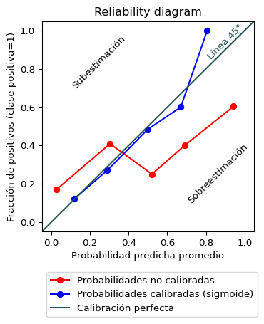

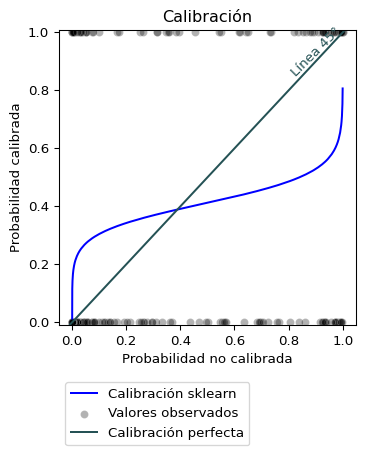

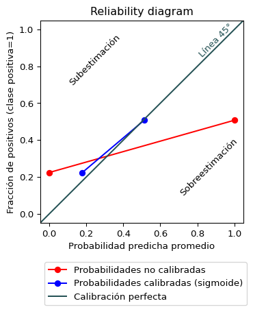

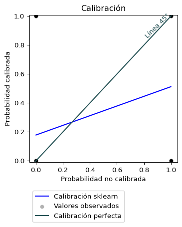

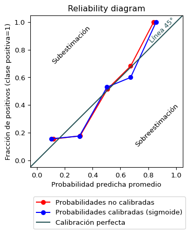

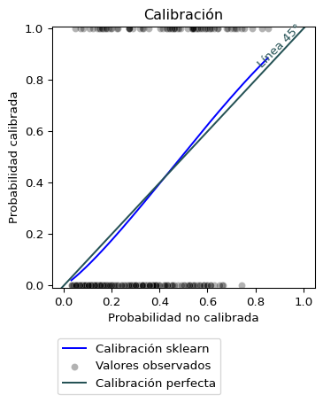

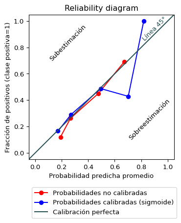

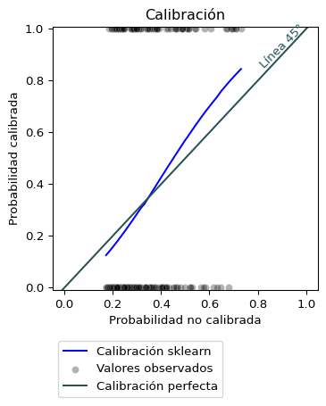

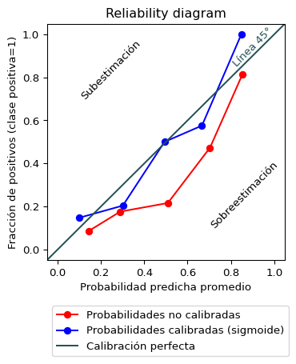

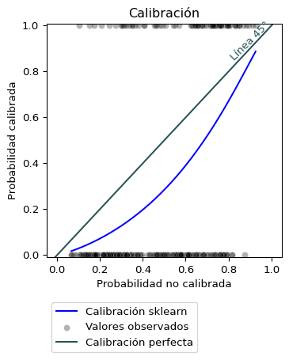

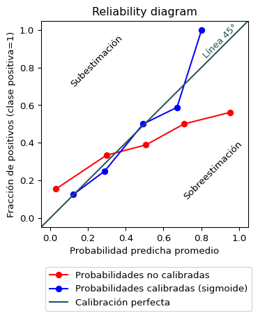

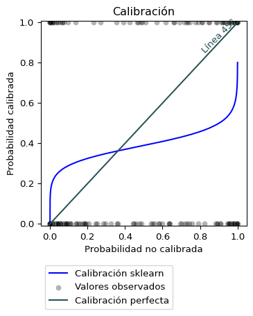

## 4.5 Calibración isotónica

Zadrozny y Elkan (2002) proponen un método alternativo al propuesto por Platt (2000): calibrar probabilidades mediante el uso de un método de regresión no paramétrico (**regresión isotónica**).

Si se asume que el modelo ordena bien, el mappeo de `scores` a probabilidades es `no decreciente`.

> Se busca minimizar el error cuadrático mediante una función escalonada no decreciente (monotónica creciente):

> $\text{Min}\sum_{i=1}^{n}(y_i - \hat{f_i})^2$

> Sujeto a $\hat{f_i}$ >= $\hat{f_j}$ siempre que $f_i$ > $f_j$

$y_i$: valor observado en la obseravción $i$

$\hat{f_i}$ probabilidad calibrada para la observación $i$

- Tiende a sobreajustar con pocos datos (Kull, Filho, y Flach 2017). En general performa mejor que el método sigmoide cuando hay más de 1000 observaciones (Niculescu-Mizil y Caruana 2005)

## 4.6 Calibración isotónica (Cont.)

- Hist gradient boosting
- Decision tree
- Logistc regression
- SVC
- Logistc regression (balanced)
- Hist gradient boosting (balanced)

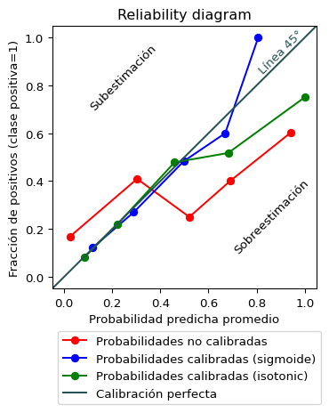

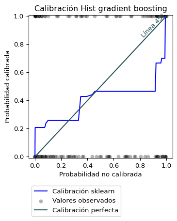

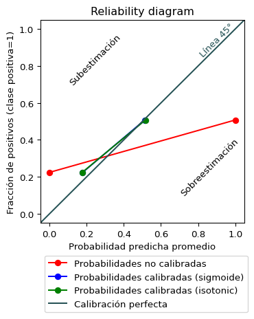

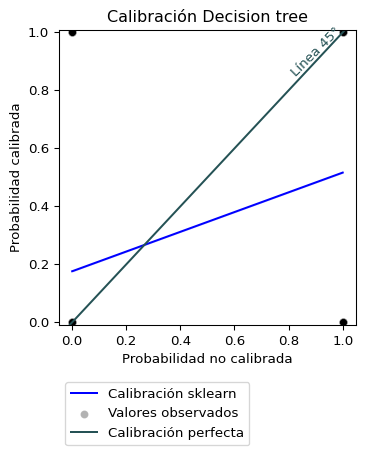

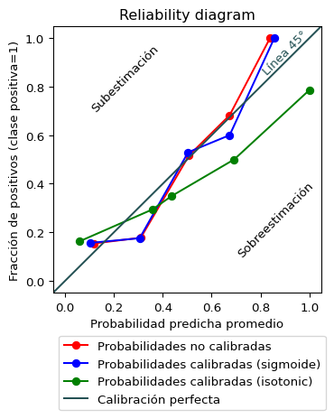

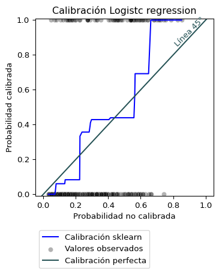

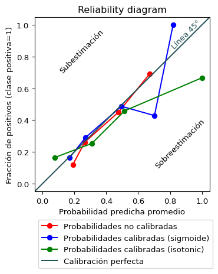

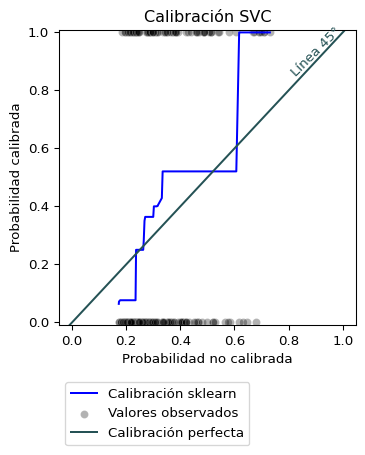

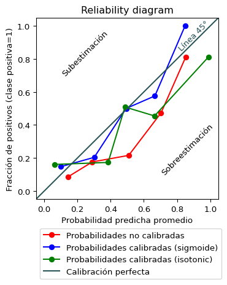

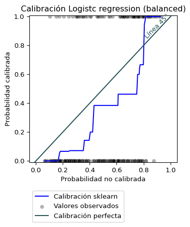

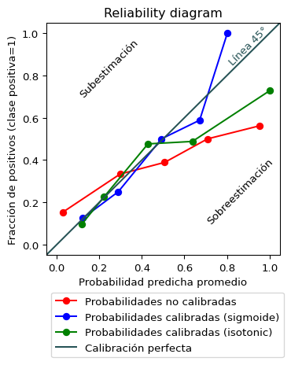

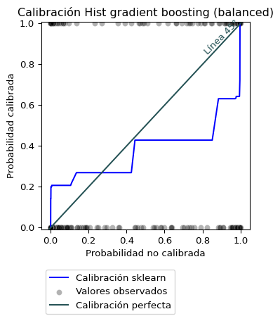

## 4.7 Comparativa de métricas

- Modelo no calibrado
- Calibración sigmoide
- Calibración isotónica

| Modelo | Clasificación |  |  |  | Ordenamiento | Probabilidad |  |
| --- | --- | --- | --- | --- | --- | --- | --- |
|  | Accuracy | Recall | Precision | F1 | ROC AUC | Log Loss | Brier Loss |
| Hist gradient boosting | 0.72 | 0.53 | 0.53 | 0.53 | 0.74 | 0.93 | 0.22 |
| Decision tree | 0.7 | 0.45 | 0.51 | 0.48 | 0.63 | 10.67 | 0.3 |
| Logistc regression | 0.74 | 0.45 | 0.59 | 0.51 | 0.75 | 0.53 | 0.18 |
| SVC | 0.73 | 0.32 | 0.6 | 0.42 | 0.71 | 0.55 | 0.19 |
| Logistc regression (balanced) | 0.64 | 0.69 | 0.44 | 0.54 | 0.75 | 0.6 | 0.21 |
| Hist gradient boosting (balanced) | 0.71 | 0.59 | 0.52 | 0.55 | 0.74 | 0.98 | 0.23 |

| Modelo | Clasificación |  |  |  | Ordenamiento | Probabilidad |  |
| --- | --- | --- | --- | --- | --- | --- | --- |
|  | Accuracy | Recall | Precision | F1 | ROC AUC | Log Loss | Brier Loss |
| Hist gradient boosting | 0.74 | 0.4 | 0.61 | 0.48 | 0.74 | 0.53 | 0.18 |
| Decision tree | 0.7 | 0.45 | 0.51 | 0.48 | 0.63 | 0.58 | 0.2 |
| Logistc regression | 0.74 | 0.45 | 0.58 | 0.51 | 0.75 | 0.53 | 0.18 |
| SVC | 0.74 | 0.32 | 0.62 | 0.42 | 0.71 | 0.55 | 0.18 |
| Logistc regression (balanced) | 0.75 | 0.47 | 0.6 | 0.53 | 0.75 | 0.53 | 0.17 |
| Hist gradient boosting (balanced) | 0.72 | 0.35 | 0.55 | 0.43 | 0.74 | 0.54 | 0.18 |

| Modelo | Clasificación |  |  |  | Ordenamiento | Probabilidad |  |
| --- | --- | --- | --- | --- | --- | --- | --- |
|  | Accuracy | Recall | Precision | F1 | ROC AUC | Log Loss | Brier Loss |
| Hist gradient boosting | 0.74 | 0.4 | 0.61 | 0.48 | 0.73 | 0.95 | 0.18 |
| Decision tree | 0.7 | 0.45 | 0.51 | 0.48 | 0.63 | 0.58 | 0.2 |
| Logistc regression | 0.74 | 0.45 | 0.58 | 0.51 | 0.74 | 1.24 | 0.19 |
| SVC | 0.74 | 0.32 | 0.62 | 0.42 | 0.71 | 1.11 | 0.19 |
| Logistc regression (balanced) | 0.75 | 0.47 | 0.6 | 0.53 | 0.75 | 1.22 | 0.19 |
| Hist gradient boosting (balanced) | 0.72 | 0.35 | 0.55 | 0.43 | 0.73 | 1.09 | 0.19 |

## 4.8 Tabla de calibración

- Hist gradient boosting
- Decision tree
- Logistc regression
- SVC
- Logistc regression (balanced)
- Hist gradient boosting (balanced)

Modelo no calibrado

| Bin | N | N Clase 1 | Probabilidad promedio | % Clase 1 (observado) | Diferencia \|avg prob - % clase 1\| |
| --- | --- | --- | --- | --- | --- |
| (-0.10%, 0.12%] | 50 | 4 | 0.00% | 8.00% | 8.00% |
| (0.12%, 1.75%] | 50 | 7 | 1.00% | 14.00% | 13.00% |
| (1.75%, 22.80%] | 50 | 14 | 8.00% | 28.00% | 20.00% |
| (22.80%, 83.70%] | 50 | 20 | 51.00% | 40.00% | 11.00% |
| (83.70%, 100.00%] | 50 | 30 | 95.00% | 60.00% | 35.00% |

Modelo calibrado (sigmoide)

| Bin | N | N Clase 1 | Probabilidad promedio | % Clase 1 (observado) | Diferencia \|avg prob - % clase 1\| |
| --- | --- | --- | --- | --- | --- |
| (1.20%, 14.10%] | 50 | 4 | 9.00% | 8.00% | 1.00% |
| (14.10%, 22.80%] | 50 | 7 | 18.00% | 14.00% | 4.00% |
| (22.80%, 35.00%] | 50 | 14 | 28.00% | 28.00% | 0.00% |
| (35.00%, 49.90%] | 50 | 20 | 41.00% | 40.00% | 1.00% |
| (49.90%, 80.70%] | 50 | 30 | 60.00% | 60.00% | 0.00% |

Modelo no calibrado

| Bin | N | N Clase 1 | Probabilidad promedio | % Clase 1 (observado) | Diferencia \|avg prob - % clase 1\| |
| --- | --- | --- | --- | --- | --- |
| (-0.10%, 100.00%] | 250 | 75 | 27.00% | 30.00% | 3.00% |

Modelo calibrado (sigmoide)

| Bin | N | N Clase 1 | Probabilidad promedio | % Clase 1 (observado) | Diferencia \|avg prob - % clase 1\| |
| --- | --- | --- | --- | --- | --- |
| (17.70%, 51.30%] | 250 | 75 | 27.00% | 30.00% | 3.00% |

Modelo no calibrado

| Bin | N | N Clase 1 | Probabilidad promedio | % Clase 1 (observado) | Diferencia \|avg prob - % clase 1\| |
| --- | --- | --- | --- | --- | --- |
| (3.02%, 11.90%] | 50 | 4 | 8.00% | 8.00% | 0.00% |
| (11.90%, 19.70%] | 50 | 11 | 15.00% | 22.00% | 7.00% |
| (19.70%, 35.60%] | 50 | 12 | 28.00% | 24.00% | 4.00% |
| (35.60%, 53.50%] | 50 | 16 | 44.00% | 32.00% | 12.00% |
| (53.50%, 85.20%] | 50 | 32 | 62.00% | 64.00% | 2.00% |

Modelo calibrado (sigmoide)

| Bin | N | N Clase 1 | Probabilidad promedio | % Clase 1 (observado) | Diferencia \|avg prob - % clase 1\| |
| --- | --- | --- | --- | --- | --- |
| (1.91%, 9.61%] | 50 | 4 | 6.00% | 8.00% | 2.00% |
| (9.61%, 17.30%] | 50 | 11 | 13.00% | 22.00% | 9.00% |
| (17.30%, 34.80%] | 50 | 12 | 26.00% | 24.00% | 2.00% |
| (34.80%, 55.10%] | 50 | 16 | 44.00% | 32.00% | 12.00% |
| (55.10%, 88.60%] | 50 | 32 | 65.00% | 64.00% | 1.00% |

Modelo no calibrado

| Bin | N | N Clase 1 | Probabilidad promedio | % Clase 1 (observado) | Diferencia \|avg prob - % clase 1\| |
| --- | --- | --- | --- | --- | --- |
| (17.10%, 21.80%] | 50 | 8 | 20.00% | 16.00% | 4.00% |
| (21.80%, 24.00%] | 50 | 8 | 23.00% | 16.00% | 7.00% |
| (24.00%, 28.80%] | 50 | 11 | 26.00% | 22.00% | 4.00% |
| (28.80%, 40.50%] | 50 | 21 | 34.00% | 42.00% | 8.00% |
| (40.50%, 73.10%] | 50 | 27 | 53.00% | 54.00% | 1.00% |

Modelo calibrado (sigmoide)

| Bin | N | N Clase 1 | Probabilidad promedio | % Clase 1 (observado) | Diferencia \|avg prob - % clase 1\| |
| --- | --- | --- | --- | --- | --- |
| (12.40%, 17.70%] | 50 | 8 | 16.00% | 16.00% | 0.00% |
| (17.70%, 20.60%] | 50 | 8 | 19.00% | 16.00% | 3.00% |
| (20.60%, 26.90%] | 50 | 11 | 23.00% | 22.00% | 1.00% |
| (26.90%, 43.30%] | 50 | 21 | 34.00% | 42.00% | 8.00% |
| (43.30%, 84.50%] | 50 | 27 | 61.00% | 54.00% | 7.00% |

Modelo no calibrado

| Bin | N | N Clase 1 | Probabilidad promedio | % Clase 1 (observado) | Diferencia \|avg prob - % clase 1\| |
| --- | --- | --- | --- | --- | --- |
| (6.54%, 23.40%] | 50 | 4 | 17.00% | 8.00% | 9.00% |
| (23.40%, 35.90%] | 50 | 10 | 29.00% | 20.00% | 9.00% |
| (35.90%, 56.80%] | 50 | 13 | 47.00% | 26.00% | 21.00% |
| (56.80%, 72.10%] | 50 | 17 | 64.00% | 34.00% | 30.00% |
| (72.10%, 92.60%] | 50 | 31 | 79.00% | 62.00% | 17.00% |

Modelo calibrado (sigmoide)

| Bin | N | N Clase 1 | Probabilidad promedio | % Clase 1 (observado) | Diferencia \|avg prob - % clase 1\| |
| --- | --- | --- | --- | --- | --- |
| (1.62%, 8.92%] | 50 | 4 | 6.00% | 8.00% | 2.00% |
| (8.92%, 16.70%] | 50 | 10 | 12.00% | 20.00% | 8.00% |
| (16.70%, 35.40%] | 50 | 13 | 26.00% | 26.00% | 0.00% |
| (35.40%, 54.90%] | 50 | 17 | 44.00% | 34.00% | 10.00% |
| (54.90%, 88.80%] | 50 | 31 | 66.00% | 62.00% | 4.00% |

Modelo no calibrado

| Bin | N | N Clase 1 | Probabilidad promedio | % Clase 1 (observado) | Diferencia \|avg prob - % clase 1\| |
| --- | --- | --- | --- | --- | --- |
| (-0.10%, 0.14%] | 50 | 5 | 0.00% | 10.00% | 10.00% |
| (0.14%, 2.85%] | 50 | 8 | 1.00% | 16.00% | 15.00% |
| (2.85%, 30.70%] | 50 | 11 | 11.00% | 22.00% | 11.00% |
| (30.70%, 88.80%] | 50 | 24 | 62.00% | 48.00% | 14.00% |
| (88.80%, 100.00%] | 50 | 27 | 97.00% | 54.00% | 43.00% |

Modelo calibrado (sigmoide)

| Bin | N | N Clase 1 | Probabilidad promedio | % Clase 1 (observado) | Diferencia \|avg prob - % clase 1\| |
| --- | --- | --- | --- | --- | --- |
| (1.34%, 14.40%] | 50 | 5 | 9.00% | 10.00% | 1.00% |
| (14.40%, 23.80%] | 50 | 8 | 19.00% | 16.00% | 3.00% |
| (23.80%, 35.10%] | 50 | 11 | 29.00% | 22.00% | 7.00% |
| (35.10%, 49.30%] | 50 | 24 | 42.00% | 48.00% | 6.00% |
| (49.30%, 80.20%] | 50 | 27 | 59.00% | 54.00% | 5.00% |

# 5 Comentarios finales

## 5.1 Comentarios finales

- En ciertos casos de modelos de clasificación podría no importar la calibración de probabilidades
- Algunos modelos tienden a estar más calibrados por defecto (regresión logística)
- Un modelo bien calibrado permite establecer puntos de corte diferenciales en función de la probabilidad predicha

[figure not shown]

Ejemplo en Google Colab

## 5.2 Referencias / Recursos

James, Gareth, Daniela Witten, Trevor Hastie, Robert Tibshirani, y Jonathan Taylor. 2023. *An Introduction to Statistical Learning with Applications in Python*. Springer Texts en Statistics. Cham: Springer. https://doi.org/10.1007/978-3-031-38747-0.

Kull, Meelis, Telmo M. Silva Filho, y Peter Flach. 2017. «Beyond sigmoids: How to obtain well-calibrated probabilities from binary classifiers with beta calibration». *Electronic Journal of Statistics* 11 (2): 5052-80. https://doi.org/10.1214/17-EJS1338SI.

Lucena, Brian. 2020. «Probability Calibration Workshop». PyData. 2020. https://www.youtube.com/watch?v=A1NGGV3Z4m4&list=PLeVfk5xTWHYBw22D52etymvcpxey4QFIk&ab_channel=numeristical.

Niculescu-Mizil, Alexandru, y Rich Caruana. 2005. «Predicting good probabilities with supervised learning». En *ICML 2005 - Proceedings of the 22nd International Conference on Machine Learning*, 625-32. https://doi.org/10.1145/1102351.1102430.

Platt, John. 2000. «Probabilistic Outputs for Support Vector Machines and Comparisons to Regularized Likelihood Methods». *Adv. Large Margin Classif.* 10 (junio).

Zadrozny, Bianca, y Charles Elkan. 2002. «Transforming Classifier Scores into Accurate Multiclass Probability Estimates». *Proceedings of the ACM SIGKDD International Conference on Knowledge Discovery and Data Mining*, agosto. https://doi.org/10.1145/775047.775151.

## 5.3 Contacto

[karinabartolome](https://www.linkedin.com/in/karinabartolome/)

karbartolome

karbartolome

[Blog](https://karbartolome-blog.netlify.app/)

[figure not shown]

Cimbage - IADCOM | Facultad de Ciencias Económicas - UBA | bit.ly/calibracion-uba | [Workshops](https://karbartolome.github.io/workshops/)